# datacode

2026-06-29

##Step 0: packages and data

```r
library(tidyverse)
library(lme4)
library(lmerTest)
library(performance)
library(emmeans)
data <- read_csv("ubelong_longitudinalData_FINAL201225_forReShare.csv",
                 show_col_types = FALSE)
```

## step1 check nesting

```r
data %>%
  count(timepoint)
```

```
## # A tibble: 2 × 2
##   timepoint     n
##   <chr>     <int>
## 1 T1         1763
## 2 T2         1763
```

```r
data %>%
  count(participant_id) %>%
  count(n)
```

```
## Storing counts in `nn`, as `n` already present in input
## ℹ Use `name = "new_name"` to pick a new name.
```

```
## # A tibble: 1 × 2
##       n    nn
##   <int> <int>
## 1     2  1763
```

```r
data %>%
  summarise(
    n_rows = n(),
    n_participants = n_distinct(participant_id),
    missing_ucla = sum(is.na(UCLA_freq)),
    missing_belonging = sum(is.na(BES_full_score)),
    missing_timepoint = sum(is.na(timepoint))
  )
```

```
## # A tibble: 1 × 5
##   n_rows n_participants missing_ucla missing_belonging missing_timepoint
##    <int>          <int>        <int>             <int>             <int>
## 1   3526           1763          986               941                 0
```

```r
data %>%
  count(participant_id) %>%
  count(n)
```

```
## Storing counts in `nn`, as `n` already present in input
## ℹ Use `name = "new_name"` to pick a new name.
```

```
## # A tibble: 1 × 2
##       n    nn
##   <int> <int>
## 1     2  1763
```

```r
data %>%
  group_by(timepoint) %>%
  summarise(
    n = n(),
    missing_ucla = sum(is.na(UCLA_freq)),
    missing_ucla_pct = mean(is.na(UCLA_freq)) * 100,
    missing_belonging = sum(is.na(BES_full_score)),
    missing_belonging_pct = mean(is.na(BES_full_score)) * 100
  )
```

```
## # A tibble: 2 × 6
##   timepoint     n missing_ucla missing_ucla_pct missing_belonging
##   <chr>     <int>        <int>            <dbl>             <int>
## 1 T1         1763          196             11.1               161
## 2 T2         1763          790             44.8               780
## # ℹ 1 more variable: missing_belonging_pct <dbl>
```

##Step 1.5：检查 T2 缺失是不是系统性的

```r
t2_status <- data %>%
  select(participant_id, timepoint, UCLA_freq, BES_full_score) %>%
  mutate(
    ucla_observed = !is.na(UCLA_freq),
    bes_observed = !is.na(BES_full_score)
  ) %>%
  group_by(participant_id) %>%
  summarise(
    t2_ucla_observed = ucla_observed[timepoint == "T2"],
    t2_bes_observed = bes_observed[timepoint == "T2"],
    .groups = "drop"
  )

t1_attrition <- data %>%
  filter(timepoint == "T1") %>%
  left_join(t2_status, by = "participant_id")
```

time2：

```r
t1_attrition %>%
  group_by(t2_ucla_observed) %>%
  summarise(
    n = n(),
    mean_t1_ucla = mean(UCLA_freq, na.rm = TRUE),
    sd_t1_ucla = sd(UCLA_freq, na.rm = TRUE),
    mean_t1_belonging = mean(BES_full_score, na.rm = TRUE),
    sd_t1_belonging = sd(BES_full_score, na.rm = TRUE)
  )
```

```
## # A tibble: 2 × 6
##   t2_ucla_observed     n mean_t1_ucla sd_t1_ucla mean_t1_belonging
##   <lgl>            <int>        <dbl>      <dbl>             <dbl>
## 1 FALSE              790         7.46       3.19              22.5
## 2 TRUE               973         7.66       3.32              23.3
## # ℹ 1 more variable: sd_t1_belonging <dbl>
```

```r
t.test(UCLA_freq ~ t2_ucla_observed, data = t1_attrition)
```

```
##
##  Welch Two Sample t-test
##
## data:  UCLA_freq by t2_ucla_observed
## t = -1.2536, df = 1562.4, p-value = 0.2102
## alternative hypothesis: true difference in means between group FALSE and group TRUE is not equal to 0
## 95 percent confidence interval:
##  -0.5292517  0.1165379
## sample estimates:
## mean in group FALSE  mean in group TRUE
##            7.457447            7.663804
```

```r
t.test(BES_full_score ~ t2_ucla_observed, data = t1_attrition)
```

```
##
##  Welch Two Sample t-test
##
## data:  BES_full_score by t2_ucla_observed
## t = -4.2228, df = 1557.8, p-value = 2.553e-05
## alternative hypothesis: true difference in means between group FALSE and group TRUE is not equal to 0
## 95 percent confidence interval:
##  -1.2489205 -0.4566708
## sample estimates:
## mean in group FALSE  mean in group TRUE
##            22.47211            23.32491
```

##Step 2: define analysis sample

```r
data_analysis <- data %>%
  mutate(
    participant_id = factor(participant_id),
    timepoint_f = factor(timepoint, levels = c("T1", "T2")),
    time_c = if_else(timepoint == "T2", 1, 0),
    surveyYear_f = factor(surveyYear),
    sex_f = factor(sex),
    yearOfStudy_f = factor(yearOfStudy)
  ) %>%
  select(
    participant_id,
    timepoint,
    timepoint_f,
    time_c,
    UCLA_freq,
    BES_full_score,
    surveyYear_f,
    sex_f,
    yearOfStudy_f
  ) %>%
  drop_na()
```

检查模型样本

```r
data_analysis %>%
  summarise(
    n_obs = n(),
    n_participants = n_distinct(participant_id)
  )
```

```
## # A tibble: 1 × 2
##   n_obs n_participants
##   <int>          <int>
## 1  2398           1584
```

```r
data_analysis %>%
  count(timepoint_f)
```

```
## # A tibble: 2 × 2
##   timepoint_f     n
##   <fct>       <int>
## 1 T1           1567
## 2 T2            831
```

```r
data_analysis %>%
  count(participant_id) %>%
  count(n)
```

```
## Storing counts in `nn`, as `n` already present in input
## ℹ Use `name = "new_name"` to pick a new name.
```

```
## # A tibble: 2 × 2
##       n    nn
##   <int> <int>
## 1     1   770
## 2     2   814
```

##step3：centering

```r
data_analysis <- data_analysis %>%
  group_by(participant_id) %>%
  mutate(
    belonging_person_mean = mean(BES_full_score),
    belonging_within = BES_full_score - belonging_person_mean
  ) %>%
  ungroup() %>%
  mutate(
    belonging_between = as.numeric(scale(
      belonging_person_mean,
      center = TRUE,
      scale = FALSE
    ))
  )
```

##model0：nonmodel

```r
m0 <- lmer(
  UCLA_freq ~ 1 + (1 | participant_id),
  data = data_analysis,
  REML = FALSE
)

summary(m0)
```

```
## Linear mixed model fit by maximum likelihood . t-tests use Satterthwaite's
##   method [lmerModLmerTest]
## Formula: UCLA_freq ~ 1 + (1 | participant_id)
##    Data: data_analysis
##
##       AIC       BIC    logLik -2*log(L)  df.resid
##   12142.8   12160.1   -6068.4   12136.8      2395
##
## Scaled residuals:
##      Min       1Q   Median       3Q      Max
## -2.62039 -0.56671 -0.08616  0.51744  3.02269
##
## Random effects:
##  Groups         Name        Variance Std.Dev.
##  participant_id (Intercept) 6.047    2.459
##  Residual                   4.522    2.126
## Number of obs: 2398, groups:  participant_id, 1584
##
## Fixed effects:
##              Estimate Std. Error        df t value Pr(>|t|)
## (Intercept) 7.428e+00  7.651e-02 1.572e+03   97.09   <2e-16 ***
## ---
## Signif. codes:  0 '***' 0.001 '**' 0.01 '*' 0.05 '.' 0.1 ' ' 1
```

```r
performance::icc(m0)
```

```
## # Intraclass Correlation Coefficient
##
##     Adjusted ICC: 0.572
##   Unadjusted ICC: 0.572
```

##model1:time effect

```r
m1 <- lmer(
  UCLA_freq ~ time_c + (1 | participant_id),
  data = data_analysis,
  REML = FALSE
)

summary(m1)
```

```
## Linear mixed model fit by maximum likelihood . t-tests use Satterthwaite's
##   method [lmerModLmerTest]
## Formula: UCLA_freq ~ time_c + (1 | participant_id)
##    Data: data_analysis
##
##       AIC       BIC    logLik -2*log(L)  df.resid
##   12124.5   12147.6   -6058.2   12116.5      2394
##
## Scaled residuals:
##     Min      1Q  Median      3Q     Max
## -2.5781 -0.5103 -0.1114  0.4864  2.9602
##
## Random effects:
##  Groups         Name        Variance Std.Dev.
##  participant_id (Intercept) 6.125    2.475
##  Residual                   4.411    2.100
## Number of obs: 2398, groups:  participant_id, 1584
##
## Fixed effects:
##               Estimate Std. Error         df t value Pr(>|t|)
## (Intercept)    7.55997    0.08185 2006.36117  92.361  < 2e-16 ***
## time_c        -0.44583    0.09835 1039.34591  -4.533 6.49e-06 ***
## ---
## Signif. codes:  0 '***' 0.001 '**' 0.01 '*' 0.05 '.' 0.1 ' ' 1
##
## Correlation of Fixed Effects:
##        (Intr)
## time_c -0.355
```

##Model 2: 加 within-person belonging

```r
m2 <- lmer(
  UCLA_freq ~ time_c + belonging_within +
    (1 | participant_id),
  data = data_analysis,
  REML = FALSE
)

summary(m2)
```

```
## Linear mixed model fit by maximum likelihood . t-tests use Satterthwaite's
##   method [lmerModLmerTest]
## Formula: UCLA_freq ~ time_c + belonging_within + (1 | participant_id)
##    Data: data_analysis
##
##       AIC       BIC    logLik -2*log(L)  df.resid
##   12099.1   12128.0   -6044.5   12089.1      2393
##
## Scaled residuals:
##     Min      1Q  Median      3Q     Max
## -2.6916 -0.5190 -0.1025  0.4775  3.1055
##
## Random effects:
##  Groups         Name        Variance Std.Dev.
##  participant_id (Intercept) 6.224    2.495
##  Residual                   4.268    2.066
## Number of obs: 2398, groups:  participant_id, 1584
##
## Fixed effects:
##                    Estimate Std. Error         df t value Pr(>|t|)
## (Intercept)         7.57525    0.08173 1996.36634  92.691  < 2e-16 ***
## time_c             -0.49896    0.09741 1032.68504  -5.123 3.60e-07 ***
## belonging_within   -0.15861    0.03004  842.90891  -5.280 1.64e-07 ***
## ---
## Signif. codes:  0 '***' 0.001 '**' 0.01 '*' 0.05 '.' 0.1 ' ' 1
##
## Correlation of Fixed Effects:
##             (Intr) time_c
## time_c      -0.351
## blngng_wthn -0.036  0.101
```

##model3：between person belonging

```r
m3 <- lmer(
  UCLA_freq ~ time_c + belonging_within + belonging_between +
    (1 | participant_id),
  data = data_analysis,
  REML = FALSE
)

summary(m3)
```

```
## Linear mixed model fit by maximum likelihood . t-tests use Satterthwaite's
##   method [lmerModLmerTest]
## Formula: UCLA_freq ~ time_c + belonging_within + belonging_between + (1 |
##     participant_id)
##    Data: data_analysis
##
##       AIC       BIC    logLik -2*log(L)  df.resid
##   11746.1   11780.8   -5867.1   11734.1      2392
##
## Scaled residuals:
##      Min       1Q   Median       3Q      Max
## -3.12593 -0.53201 -0.05768  0.48686  3.13867
##
## Random effects:
##  Groups         Name        Variance Std.Dev.
##  participant_id (Intercept) 4.444    2.108
##  Residual                   4.219    2.054
## Number of obs: 2398, groups:  participant_id, 1584
##
## Fixed effects:
##                     Estimate Std. Error         df t value Pr(>|t|)
## (Intercept)          7.53587    0.07433 2088.25283 101.381  < 2e-16 ***
## time_c              -0.42828    0.09579 1099.66193  -4.471 8.59e-06 ***
## belonging_within    -0.15640    0.02986  870.28909  -5.237 2.04e-07 ***
## belonging_between   -0.34715    0.01744 1631.64652 -19.910  < 2e-16 ***
## ---
## Signif. codes:  0 '***' 0.001 '**' 0.01 '*' 0.05 '.' 0.1 ' ' 1
##
## Correlation of Fixed Effects:
##             (Intr) time_c blngng_w
## time_c      -0.388
## blngng_wthn -0.039  0.100
## blngng_btwn  0.027 -0.033 -0.003
```

##model4 covirates

```r
m4 <- lmer(
  UCLA_freq ~ time_c + belonging_within + belonging_between +
    surveyYear_f + sex_f + yearOfStudy_f +
    (1 | participant_id),
  data = data_analysis,
  REML = FALSE
)

summary(m4)
```

```
## Linear mixed model fit by maximum likelihood . t-tests use Satterthwaite's
##   method [lmerModLmerTest]
## Formula:
## UCLA_freq ~ time_c + belonging_within + belonging_between + surveyYear_f +
##     sex_f + yearOfStudy_f + (1 | participant_id)
##    Data: data_analysis
##
##       AIC       BIC    logLik -2*log(L)  df.resid
##   11741.5   11828.2   -5855.7   11711.5      2383
##
## Scaled residuals:
##     Min      1Q  Median      3Q     Max
## -3.0244 -0.5405 -0.0704  0.4819  3.1743
##
## Random effects:
##  Groups         Name        Variance Std.Dev.
##  participant_id (Intercept) 4.333    2.082
##  Residual                   4.223    2.055
## Number of obs: 2398, groups:  participant_id, 1584
##
## Fixed effects:
##                         Estimate Std. Error         df t value Pr(>|t|)
## (Intercept)              7.32673    0.31701 1649.74470  23.112  < 2e-16 ***
## time_c                  -0.43430    0.09580 1098.50536  -4.533 6.45e-06 ***
## belonging_within        -0.15659    0.02987  868.66492  -5.242 2.00e-07 ***
## belonging_between       -0.35149    0.01739 1625.92505 -20.210  < 2e-16 ***
## surveyYear_f2024-2025   -0.51147    0.14447 1566.08830  -3.540 0.000411 ***
## sex_f2                   0.04457    0.15680 1553.19082   0.284 0.776280
## sex_f3                   0.24925    2.62295 1278.27424   0.095 0.924310
## sex_f88                  0.16267    0.69647 1510.49743   0.234 0.815355
## yearOfStudy_f1           0.55836    0.29911 1644.05261   1.867 0.062119 .
## yearOfStudy_f2           0.70710    0.50983 1623.70705   1.387 0.165650
## yearOfStudy_f3           0.30266    0.71511 1723.55329   0.423 0.672176
## yearOfStudy_f4           0.80466    0.92923 1755.53073   0.866 0.386640
## yearOfStudy_f5          -0.13891    0.49917 1713.62553  -0.278 0.780830
## ---
## Signif. codes:  0 '***' 0.001 '**' 0.01 '*' 0.05 '.' 0.1 ' ' 1
```

```
##
## Correlation matrix not shown by default, as p = 13 > 12.
## Use print(x, correlation=TRUE)  or
##     vcov(x)        if you need it
```

##Model comparison

```r
anova(m0, m1, m2, m3, m4)
```

```
## Data: data_analysis
## Models:
## m0: UCLA_freq ~ 1 + (1 | participant_id)
## m1: UCLA_freq ~ time_c + (1 | participant_id)
## m2: UCLA_freq ~ time_c + belonging_within + (1 | participant_id)
## m3: UCLA_freq ~ time_c + belonging_within + belonging_between + (1 | participant_id)
## m4: UCLA_freq ~ time_c + belonging_within + belonging_between + surveyYear_f + sex_f + yearOfStudy_f + (1 | participant_id)
##    npar   AIC   BIC  logLik -2*log(L)   Chisq Df Pr(>Chisq)
## m0    3 12143 12160 -6068.4     12137
## m1    4 12124 12148 -6058.2     12116  20.288  1  6.661e-06 ***
## m2    5 12099 12128 -6044.5     12089  27.418  1  1.639e-07 ***
## m3    6 11746 11781 -5867.1     11734 354.936  1  < 2.2e-16 ***
## m4   15 11742 11828 -5855.7     11712  22.639  9    0.00706 **
## ---
## Signif. codes:  0 '***' 0.001 '**' 0.01 '*' 0.05 '.' 0.1 ' ' 1
```

```r
AIC(m0, m1, m2, m3, m4)
```

```
##    df      AIC
## m0  3 12142.78
## m1  4 12124.49
## m2  5 12099.07
## m3  6 11746.13
## m4 15 11741.50
```

```r
BIC(m0, m1, m2, m3, m4)
```

```
##    df      BIC
## m0  3 12160.12
## m1  4 12147.62
## m2  5 12127.98
## m3  6 11780.83
## m4 15 11828.23
```

##random slope check

##model4 as retained model

```r
m4 <- lmer(
  UCLA_freq ~ time_c + belonging_within + belonging_between +
    surveyYear_f + sex_f + yearOfStudy_f +
    (1 | participant_id),
  data = data_analysis,
  REML = FALSE
)
```

##final REML model

```r
m_final <- lmer(
  UCLA_freq ~ time_c + belonging_within + belonging_between +
    surveyYear_f + sex_f + yearOfStudy_f +
    (1 | participant_id),
  data = data_analysis,
  REML = TRUE
)

summary(m_final)
```

```
## Linear mixed model fit by REML. t-tests use Satterthwaite's method [
## lmerModLmerTest]
## Formula:
## UCLA_freq ~ time_c + belonging_within + belonging_between + surveyYear_f +
##     sex_f + yearOfStudy_f + (1 | participant_id)
##    Data: data_analysis
##
## REML criterion at convergence: 11726.2
##
## Scaled residuals:
##     Min      1Q  Median      3Q     Max
## -3.0201 -0.5379 -0.0719  0.4795  3.1675
##
## Random effects:
##  Groups         Name        Variance Std.Dev.
##  participant_id (Intercept) 4.377    2.092
##  Residual                   4.233    2.057
## Number of obs: 2398, groups:  participant_id, 1584
##
## Fixed effects:
##                         Estimate Std. Error         df t value Pr(>|t|)
## (Intercept)              7.32657    0.31812 1638.03329  23.031  < 2e-16 ***
## time_c                  -0.43470    0.09595 1094.65652  -4.531 6.53e-06 ***
## belonging_within        -0.15660    0.02991  866.36437  -5.236 2.06e-07 ***
## belonging_between       -0.35149    0.01745 1614.50508 -20.140  < 2e-16 ***
## surveyYear_f2024-2025   -0.51114    0.14498 1555.32394  -3.525 0.000435 ***
## sex_f2                   0.04463    0.15736 1542.56607   0.284 0.776733
## sex_f3                   0.24987    2.63288 1270.46304   0.095 0.924405
## sex_f88                  0.16215    0.69897 1500.33083   0.232 0.816588
## yearOfStudy_f1           0.55835    0.30016 1632.43538   1.860 0.063038 .
## yearOfStudy_f2           0.70660    0.51162 1612.31131   1.381 0.167436
## yearOfStudy_f3           0.30204    0.71757 1711.06314   0.421 0.673864
## yearOfStudy_f4           0.80403    0.93240 1742.69456   0.862 0.388629
## yearOfStudy_f5          -0.14007    0.50088 1701.24239  -0.280 0.779779
## ---
## Signif. codes:  0 '***' 0.001 '**' 0.01 '*' 0.05 '.' 0.1 ' ' 1
```

```
##
## Correlation matrix not shown by default, as p = 13 > 12.
## Use print(x, correlation=TRUE)  or
##     vcov(x)        if you need it
```

```r
performance::icc(m_final)
```

```
## # Intraclass Correlation Coefficient
##
##     Adjusted ICC: 0.508
##   Unadjusted ICC: 0.412
```

```r
performance::r2_nakagawa(m_final)
```

```
## # R2 for Mixed Models
##
##   Conditional R2: 0.602
##      Marginal R2: 0.190
```

用 time、within-person belonging、between-person belonging 和 covariates 预测 UCLA loneliness，并允许每个 participant 有自己的 random intercept。

也就是：

fixed effects：平均效应； random intercept：每个学生有自己的平均 loneliness 水平； 没有 random slope：因为数据不支持估计 individual change slope。

###A. Assumption checks

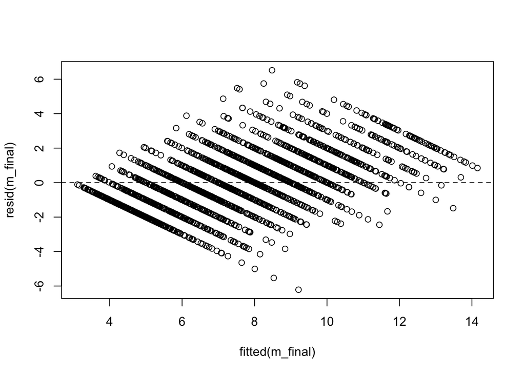

```r
# Residuals vs fitted: check homoscedasticity / nonlinearity
plot(fitted(m_final), resid(m_final))
abline(h = 0, lty = 2)
```

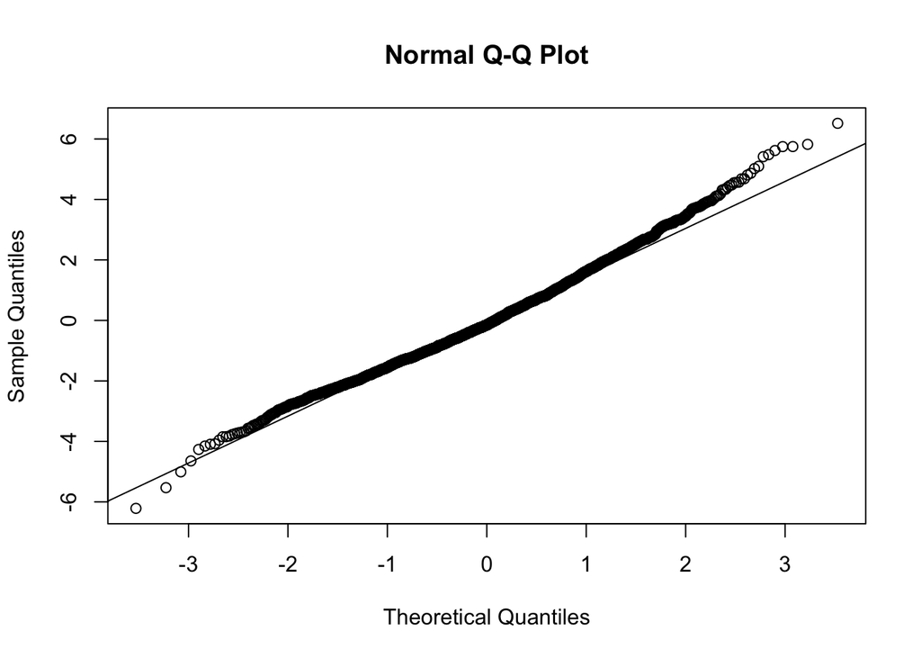

```r
# Normality of level-1 residuals
qqnorm(resid(m_final))
qqline(resid(m_final))
```

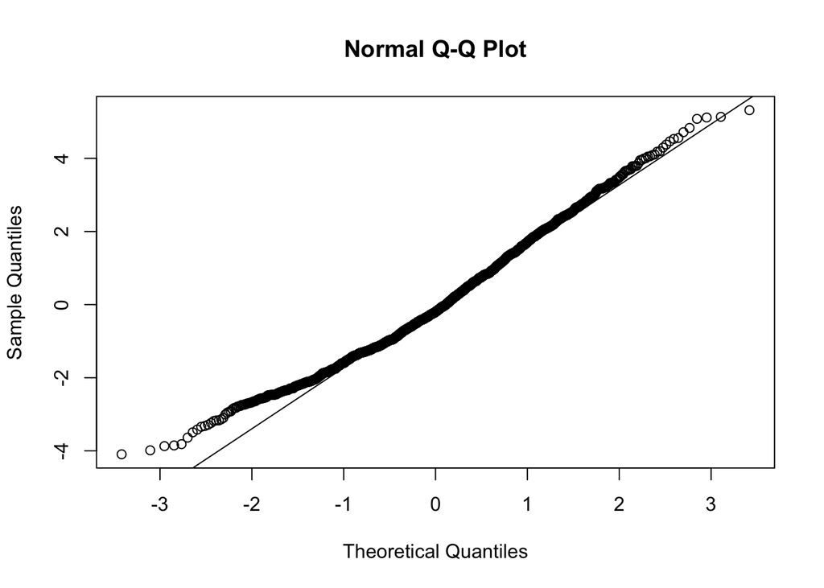

```r
# Normality of random intercepts
ranef_values <- ranef(m_final)$participant_id[, "(Intercept)"]
qqnorm(ranef_values)
qqline(ranef_values)
```

###B. Complete two-wave sensitivity analysis（for t2 missing）

```r
complete_ids <- data_analysis %>%
  count(participant_id) %>%
  filter(n == 2) %>%
  pull(participant_id)

data_complete2 <- data_analysis %>%
  filter(participant_id %in% complete_ids)

m_final_complete2 <- lmer(
  UCLA_freq ~ time_c + belonging_within + belonging_between +
    surveyYear_f + sex_f + yearOfStudy_f +
    (1 | participant_id),
  data = data_complete2,
  REML = TRUE
)

summary(m_final_complete2)
```

```
## Linear mixed model fit by REML. t-tests use Satterthwaite's method [
## lmerModLmerTest]
## Formula:
## UCLA_freq ~ time_c + belonging_within + belonging_between + surveyYear_f +
##     sex_f + yearOfStudy_f + (1 | participant_id)
##    Data: data_complete2
##
## REML criterion at convergence: 7913.4
##
## Scaled residuals:
##      Min       1Q   Median       3Q      Max
## -2.93356 -0.55311 -0.06144  0.50427  3.11392
##
## Random effects:
##  Groups         Name        Variance Std.Dev.
##  participant_id (Intercept) 4.545    2.132
##  Residual                   4.299    2.073
## Number of obs: 1628, groups:  participant_id, 814
##
## Fixed effects:
##                        Estimate Std. Error        df t value Pr(>|t|)
## (Intercept)             7.67522    0.45325 824.15740  16.934  < 2e-16 ***
## time_c                 -0.53782    0.10337 812.00001  -5.203 2.49e-07 ***
## belonging_within       -0.15983    0.03017 812.00001  -5.298 1.51e-07 ***
## belonging_between      -0.35059    0.02461 802.99998 -14.245  < 2e-16 ***
## surveyYear_f2024-2025  -0.96454    0.19122 802.99998  -5.044 5.63e-07 ***
## sex_f2                 -0.04526    0.20505 802.99998  -0.221  0.82536
## sex_f3                 -0.76915    2.79823 802.99998  -0.275  0.78349
## sex_f88                 0.66178    0.87613 802.99998   0.755  0.45026
## yearOfStudy_f1          0.66093    0.43101 802.99998   1.533  0.12556
## yearOfStudy_f2          1.47283    0.71888 802.99998   2.049  0.04081 *
## yearOfStudy_f3          1.47955    1.14273 802.99998   1.295  0.19578
## yearOfStudy_f4          2.10198    1.55210 802.99998   1.354  0.17603
## yearOfStudy_f5          2.18433    0.78856 802.99998   2.770  0.00573 **
## ---
## Signif. codes:  0 '***' 0.001 '**' 0.01 '*' 0.05 '.' 0.1 ' ' 1
```

```
##
## Correlation matrix not shown by default, as p = 13 > 12.
## Use print(x, correlation=TRUE)  or
##     vcov(x)        if you need it
```

```r
performance::r2_nakagawa(m_final_complete2)
```

```
## # R2 for Mixed Models
##
##   Conditional R2: 0.605
##      Marginal R2: 0.187
```